# H-1B Visa Trends

data science

Author

David Rios, Bernarda Perez, Nayla Trigueros, Yoselyn Rodriguez

Published

December 8, 2025

## Introduction

Most Americans never face the extensive sponsorship requirements necessary to secure employment authorization. As Latinx students from immigrant backgrounds, we’ve witnessed the complex visa application process firsthand, motivating us to investigate: **What employment features increase the likelihood of H-1B visa certification?**

This dataset originates from the U.S. Department of Labor and was accessed through Kaggle, spanning 2020-2023. Given the dataset’s size, we cleaned the data to focus on H-1B visas for U.S. employment, then drew a stratified random sample of 1% (~33,000 observations) while preserving noisiness. We hypothesize that occupation type, geographical location, application timing, and wage levels will influence certification outcomes.

## Uploading Libraries

```r
# Libraries
library(tidyverse)
library(lubridate)
library(ggthemes)
library(plotly)
library(leaflet)
```

### Importing the Data

```r
# Uploading the 1%-stratified sample
visas <- read_csv("~/Library/CloudStorage/Dropbox/hriostorres.gihub.io/data/visas_sample.csv")

# Aggregating our variables of interest
visas <- visas %>%
  mutate(SOC_CODE = str_sub(SOC_CODE, 1, 2)) %>%
  mutate(SOC_TITLE = case_when( #code gotten from stackoverflow
    SOC_CODE == "11" ~ "Management",
    SOC_CODE == "13" ~ "Business and Financial Operations",
    SOC_CODE == "15" ~ "Computer and Mathematical",
    SOC_CODE == "17" ~ "Architecture and Engineering",
    SOC_CODE == "19" ~ "Life, Physical, and Social Science",
    SOC_CODE == "21" ~ "Community and Social Service",
    SOC_CODE == "23" ~ "Legal",
    SOC_CODE == "25" ~ "Educational Instruction and Library",
    SOC_CODE == "27" ~ "Arts, Design, Entertainment, Sports, and Media",
    SOC_CODE == "29" ~ "Healthcare Practitioners and Technical",
    SOC_CODE == "31" ~ "Healthcare Support",
    SOC_CODE == "33" ~ "Protective Service",
    SOC_CODE == "35" ~ "Food Preparation and Serving Related",
    SOC_CODE == "37" ~ "Building and Grounds Cleaning and Maintenance",
    SOC_CODE == "39" ~ "Personal Care and Service",
    SOC_CODE == "41" ~ "Sales and Related",
    SOC_CODE == "43" ~ "Office and Administrative Support",
    SOC_CODE == "45" ~ "Farming, Fishing, and Forestry",
    SOC_CODE == "47" ~ "Construction and Extraction",
    SOC_CODE == "49" ~ "Installation, Maintenance, and Repair",
    SOC_CODE == "51" ~ "Production",
    SOC_CODE == "53" ~ "Transportation and Material Moving",
    SOC_CODE == "55" ~ "Military Specific",
    TRUE ~ "Other"))

grouped_soc_title <-visas %>%
  filter (CASE_STATUS == "Certified") %>%
  count(SOC_TITLE) %>%
  arrange(desc(n))

visas <- visas %>%
  mutate(year = year(RECEIVED_DATE),
         n_week = week(RECEIVED_DATE),
         n_month = month(RECEIVED_DATE)) %>%
  filter ((year < 2024),
           (EMPLOYER_COUNTRY == "UNITED STATES OF AMERICA"))
```

## Occupation

We first observe how different occupational categories affect H-1B visa certification outcomes.

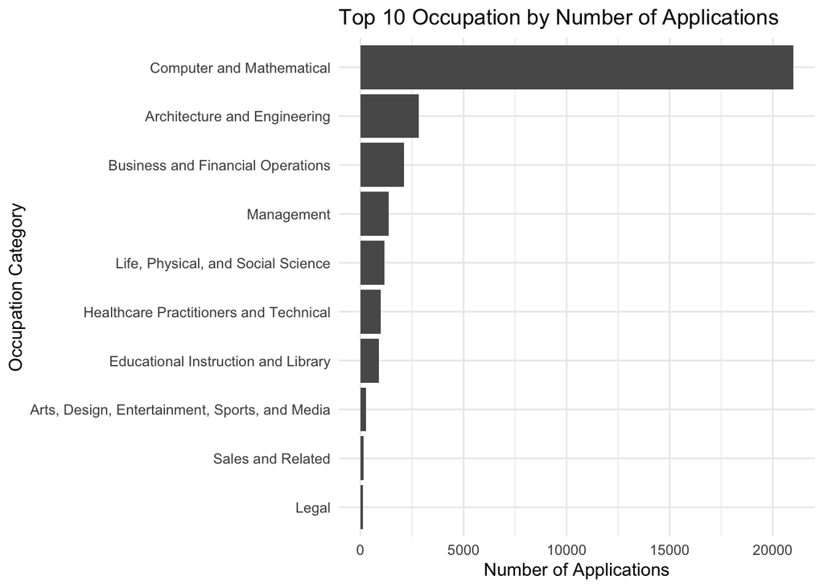

This graph shows how Computer and Mathematical occupations dominate the H1-B application.

```r
# Showing top 10 ocupations arranged by application volume
grouped_soc_title %>%
  arrange(desc(n)) %>%
  slice(1:10) %>%
  mutate(SOC_TITLE = fct_reorder(SOC_TITLE, n)) %>%
  ggplot(aes(x = n, y = SOC_TITLE)) +
  geom_col() +
  labs(
    title = "Top 10 Occupation by Number of Applications",
    x = "Number of Applications",
    y = "Occupation Category") +
  theme_minimal()
```

### Case Status Distribution For Visa Applications in Top 10 Occupations

```r
visas_occ <- visas %>%
  count(SOC_TITLE) %>%
  arrange(desc(n)) %>%
  slice(1:10)

p <- visas %>%
  count(SOC_TITLE, CASE_STATUS) %>%
  semi_join(visas_occ, by = "SOC_TITLE") %>%
  left_join(visas_occ, by = "SOC_TITLE") %>%
  group_by(SOC_TITLE) %>%
  mutate(pct = round(n.x / sum(n.x), 3)) %>%
  ungroup() %>%
 ggplot(aes(
      x = fct_reorder(SOC_TITLE, n.y),
      y = pct,
      fill = CASE_STATUS,
      text = paste0(
        "Industry: ", SOC_TITLE,
        "<br>Case status: ", CASE_STATUS,
        "<br>Percentage: ", scales::percent(pct, accuracy = 0.1),
        "<br>Applications: ", n.x))) +
  geom_col() +
  theme_minimal() +
  labs(y = "Percentage",
       x = "Industries",
       fill = "Case Status",
       title  = "Visa Applications per Occupations (2020-2023)") +
  coord_flip()

ggplotly(p, tooltip = c("text"))
```

[interactive chart not shown]

Despite volume differences, certification rates remain consistent across occupations, with most categories exceeding 90%. Life, Physical, and Social Science occupations show slightly higher “Certified-Withdrawn” cases, while denial rates remain minimal across all categories. The lower application volumes in certain categories limit our ability to assess occupation as a predictor of certification.

### Decision Timeline By Occupation

```r
# Cleaning Timeline Data

# Converting dates from chr to int
visas$RECEIVED_DATE <- as.Date(visas$RECEIVED_DATE)
visas$DECISION_DATE <- as.Date(visas$DECISION_DATE)

# Calculating timeline in months
visas$VISA_TIMELINE <- as.numeric(visas$DECISION_DATE - visas$RECEIVED_DATE) / 30.44
```

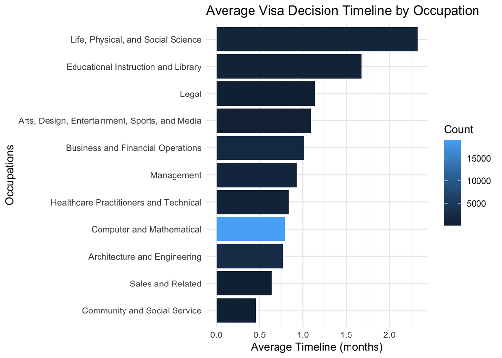

Average visa decision timeline by occupation category. Processing times range from 0.5 months (Community and Social Service) to 2.3 months (Life, Physical, and Social Science).

```r
visas %>%
  group_by(SOC_TITLE) %>%
  summarise(
    avg_timeline = mean(VISA_TIMELINE, na.rm = TRUE),
    count = n()
  ) %>%
  slice_max(count, n = 10) %>%  # Add this line to get top 10 by count
  arrange(avg_timeline) %>%
  mutate(SOC_TITLE = fct_inorder(SOC_TITLE)) %>%
  ggplot(aes(x = avg_timeline, y = SOC_TITLE, fill = count)) +
  geom_col() +
  labs(title = "Average Visa Decision Timeline by Occupation",
       x = "Average Timeline (months)",
       y = "Occupations",
       fill = "Count") +
  theme_minimal()
```

Processing times vary considerably. Life, Physical, and Social Science applications take over 2 months, while Community and Social Service applications are decided in under one month. Computer and Mathematical occupations experience relatively short processing times despite high volume, suggesting possible prioritization of economically significant industries.

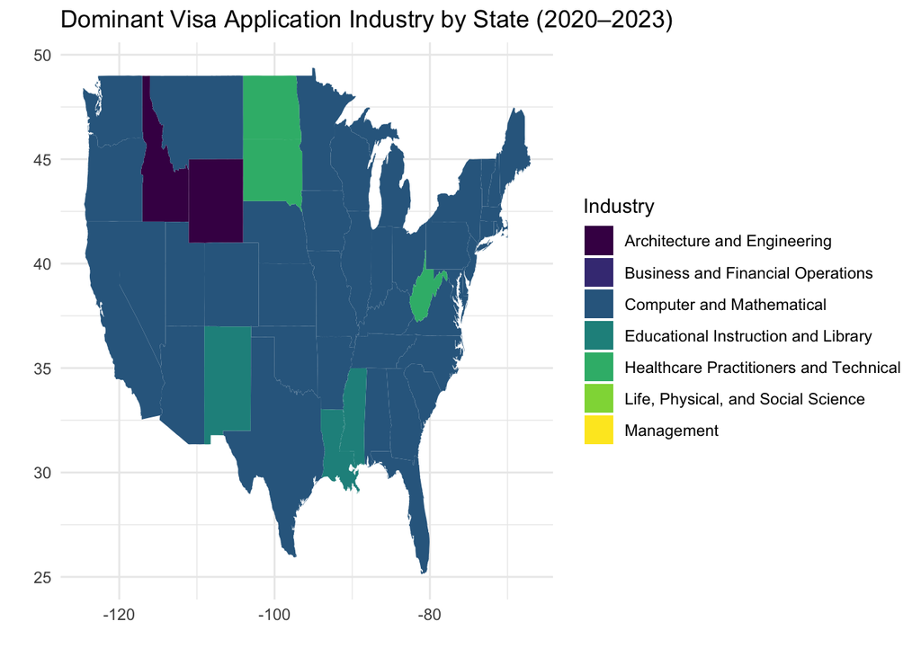

We see that Computer and Mathematical Occupations dominate the H1-B application in most states.

```r
# Setting up the map: Longitude and latitude for each state
states_map <- map_data("state")

# Getting dominant industry per state
dominant_industry <- visas %>%
  group_by(EMPLOYER_STATE, SOC_TITLE) %>%
  summarise(total_applications = n(), .groups = "drop") %>%
  group_by(EMPLOYER_STATE) %>%
  slice_max(total_applications, n = 1) %>%
  ungroup() %>%
  mutate(EMPLOYER_STATE = tolower(state.name[match(EMPLOYER_STATE, state.abb)]))

# Creating a map that shows the dominant industry per state
ggplot(dominant_industry, aes(map_id = EMPLOYER_STATE, fill = SOC_TITLE)) +
  geom_map(map = states_map) +
  expand_limits(x = states_map$long, y = states_map$lat) +
  labs(fill = "Industry",
    x = "",
    y = "",
    title = "Dominant Visa Application Industry by State (2020–2023)") +
  scale_fill_viridis_d(drop = TRUE) +
  theme_minimal()
```

The map above reveals Computer and Mathematical occupations dominate H-1B applications nationwide, particularly in East and West Coast states. These patterns demonstrate that occupation type hugely influences application volume and processing duration. While certification rates appear consistent, the shorter processing times for Computer and Mathematical occupations suggest potential prioritization, likely reflecting both the F-1-to-H-1B pipeline with STEM OPT extensions and tech industry reliance on foreign talent.

## Geographical Location

Our analysis now turns to how geographical location influences H-1B visa certification outcomes and application patterns across different states and regions.

### Total Visa Applications per State

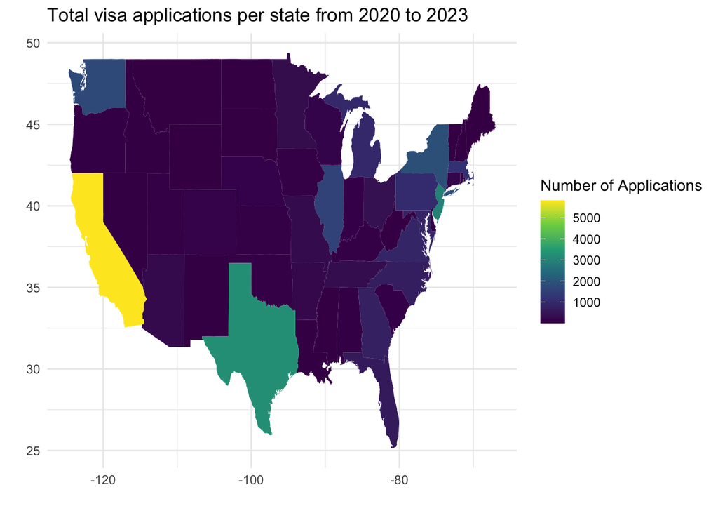

H-1B application volume concentrates heavily in California, Texas, New York, and Washington.

```r
# Setting up the map: Longitude and latitude for each state
states_map <- map_data("state")

# Creating a map that shows the number of visas given per state
visas_map <- visas %>%
  group_by(EMPLOYER_STATE) %>%
  summarise(number_of_visas = n()) %>%
  mutate(EMPLOYER_STATE = tolower(state.name[match(EMPLOYER_STATE, state.abb)]))
ggplot(visas_map, aes(map_id = EMPLOYER_STATE, fill = number_of_visas)) +
  geom_map(map = states_map) +
  expand_limits(x = states_map$long, y = states_map$lat) +
  labs(fill = "Number of Applications", x="", y="", title = "Total visa applications per state from 2020 to 2023") +
  scale_fill_viridis_c() +
  theme_minimal()
```

H-1B application volume concentrates heavily in major tech hubs. California accounts for over 5,000 applications, far surpassing other states, with Texas, New York, and Washington also showing high volumes. Most states show minimal application activity, revealing geographic clustering in established technology centers.

### Percentage of Certified H1B Applications by State

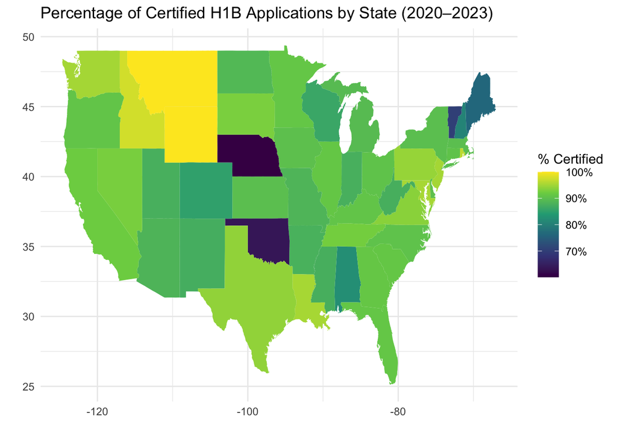

Most states maintain certification rates above 90%, with few exceptions showing rates below 70%.

```r
# Data wrangling for geographical exploration
visas_map <- visas %>%
  group_by(EMPLOYER_STATE) %>%
  summarise(
    certified = sum(CASE_STATUS == "Certified", na.rm = TRUE),
    total = n(),
    pct_certified = certified / total
  ) %>%
  mutate(
    EMPLOYER_STATE = tolower(state.name[match(EMPLOYER_STATE, state.abb)])
  )
# Map of certified applications by state
ggplot(visas_map, aes(map_id = EMPLOYER_STATE, fill = pct_certified)) +
  geom_map(map = states_map) +
  expand_limits(x = states_map$long, y = states_map$lat) +
  scale_fill_viridis_c(labels = scales::percent) +
  labs(
    fill = "% Certified",
    title = "Percentage of Certified H1B Applications by State (2020–2023)",
    x = "", y = ""
  ) +
  theme_minimal()
```

```r
# Data wrangling for visualization
visas_zip <- visas %>%
  group_by(EMPLOYER_POSTAL_CODE) %>%
  count(EMPLOYER_POSTAL_CODE) %>%
  arrange(desc(n)) %>%
  head(10)

# Create location data with coordinates
location_data <- tibble(
  EMPLOYER_POSTAL_CODE = c("98121", "77845", "94043", "95054", "98052",
                           "20850", "75082", "19103", "94025", "07094"),
  latitude = c(47.61, 30.5, 37.41, 37.40, 47.68,
               39.09, 32.99, 39.95, 37.46, 40.78),
  longitude = c(-122.35, -96.3, -122.09, -121.96, -122.12,
                -77.19, -96.66, -75.17, -122.18, -74.06),
  county = c("King County", "Brazos County", "Santa Clara County",
             "Santa Clara County", "King County", "Montgomery County",
             "Collin County", "Philadelphia County", "San Mateo County",
             "Hudson County"),
  city = c("Seattle", "College Station", "Mountain View", "Santa Clara",
           "Redmond", "Rockville", "Richardson", "Philadelphia",
           "Menlo Park", "Secaucus"),
  state = c("WA", "TX", "CA", "CA", "WA", "MD", "TX", "PA", "CA", "NJ"),
  country = "USA")

visas_zip_mapped <- visas_zip %>%
  left_join(location_data, by = "EMPLOYER_POSTAL_CODE")

# Color palette for states
pal <- colorFactor(palette = "Set3",
                   levels = unique(visas_zip_mapped$state))

leaflet(data = visas_zip_mapped) %>%
  addTiles() %>%
  addCircleMarkers(
    lng = ~longitude,
    lat = ~latitude,
    label = ~paste0(city, ": ", n, " applications"),
    color = ~pal(state),
    radius = 10,
    opacity = 10) %>%
  addLegend(pal = pal,
    values = ~state,
    title = "States") %>%
  addControl(
    "<strong>Top 10 H-1B Visa Employer Locations in the US</strong>",
    position = "topleft")
```

[interactive chart not shown]

Top 10 H-1B visa employer locations in the US

The interactive map reveals the top employer locations: Santa Clara, Mountain View, and Menlo Park—the heart of Silicon Valley—dominate the H-1B market. This concentration aligns with STEM occupations’ dominance in applications.

These patterns demonstrate that while application volume concentrates in tech-dominant states, location has limited influence on certification outcomes overall, with most states maintaining high approval rates. We now shift towards application filing time.

## Time

Next, we look at application timing in H-1B applications to identify whether filing time influences certification outcomes and application volume.

### Filing Month Impact on Visa Certification

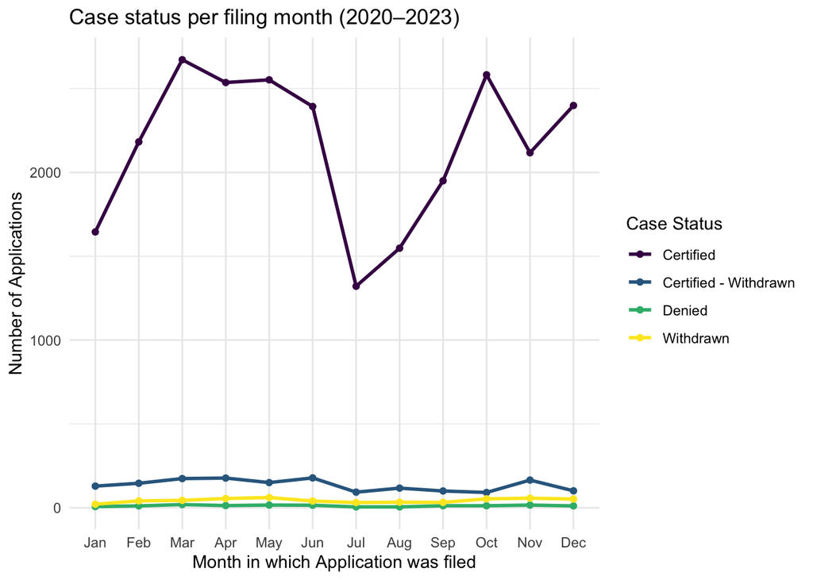

Application volume peaks in March and October, with certified applications following total volume throughout the year.

```r
# Wrangling and plotting case status per month
visas %>%
  filter(year >= 2020, !is.na(RECEIVED_DATE)) %>%
  mutate(month_num = month(RECEIVED_DATE),
         month = factor(month.abb[month_num], levels =(month.abb))) %>%
  count(month, CASE_STATUS) %>%
  ggplot(aes(x = month, y = n, color = CASE_STATUS, group = CASE_STATUS)) +
  geom_line(linewidth = 1) +
  geom_point() +
  labs(
    y = "Number of Applications",
    x = "Month in which Application was filed",
    color = "Case Status",
    title = "Case status per filing month (2020–2023)") +
  theme_minimal() +
  scale_color_viridis_d()
```

Applications show distinct seasonal patterns, with peak filing in March and October. March experiences the highest volume with nearly 3,000 applications, followed by April and May, reflecting the traditional H-1B filing season. October’s secondary peak coincides with the fiscal year start, while July shows the lowest volume due to the annual cap-driven cycle’s completion. So we continue exploring.

### Visa Applications Across Years

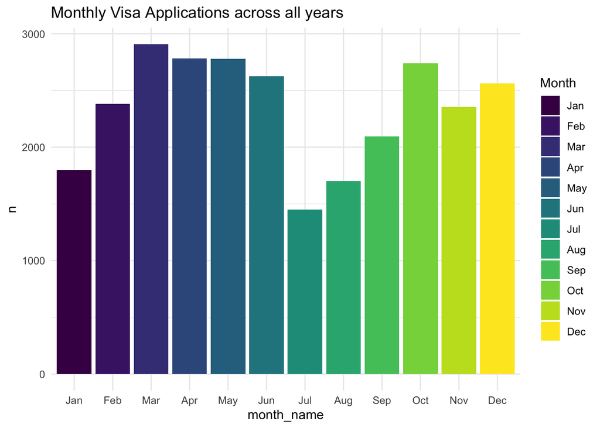

March has the highest application volume at nearly 3,000, followed by April and May, with July showing the lowest volume.

```r
visas %>%
  filter(year >= 2020) %>%
  mutate(month = month(RECEIVED_DATE),
          month_name = factor(month(RECEIVED_DATE, label = TRUE),
                            levels = month.abb)) %>%
  count(month, month_name) %>%
  group_by(month) %>%
  ggplot(aes(x = month_name, y = n, fill=month_name)) +
  geom_col() +
  labs(title = "Monthly Visa Applications across all years") +
  scale_fill_viridis_d("Month") +
  theme_minimal()
```

### Visa Certifications Across Months

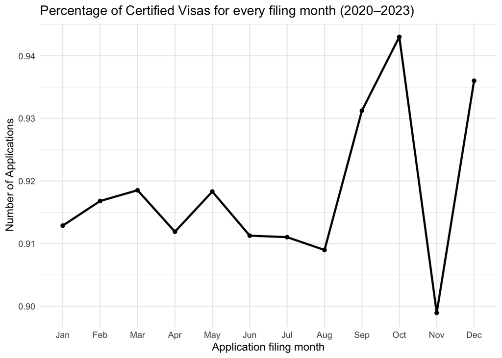

```r
visas_certified <- visas %>%
  filter(year >= 2020, !is.na(RECEIVED_DATE)) %>%
  mutate(month_num = month(RECEIVED_DATE),
         month = factor(month.abb[month_num], levels =(month.abb))) %>%
  count(month, CASE_STATUS) %>%
  group_by(month) %>%
  mutate(total_applications = sum(n),
         rate_per_case_status = n/total_applications) %>%
  filter (CASE_STATUS == "Certified")



 ggplot(visas_certified, aes(x = month, y = rate_per_case_status, group = CASE_STATUS)) +
  geom_line(linewidth = 1) +
  geom_point() +
  labs(
    y = "Number of Applications",
    x = "Application filing month",
    color = "Case Status",
    title = "Percentage of Certified Visas for every filing month (2020–2023)") +
  scale_color_viridis_d() + theme_minimal()
```

The consistency in certification rates across most months, with only minor variations tied to seasonal pressures, suggests timing itself is not a major determinant of approval. Variations appear more closely related to administrative capacity during peak periods rather than systematic bias by month, indicating applicants need not strategically time applications to maximize approval chances.

## Wage

Finally, we examine how wage levels influence H-1B visa certification outcomes, as prevailing wage requirements are a key component of the application process.

### Wage Distribution Per Case Status

```r
# Cleaning Wage Data

# Convert all wages to yearly
visas <- visas %>%
  mutate(Yearly_wage = case_when(
    PW_UNIT_OF_PAY == "Hour"  ~ PREVAILING_WAGE * 40 * 52,
    PW_UNIT_OF_PAY == "Week"  ~ PREVAILING_WAGE * 52,
    PW_UNIT_OF_PAY == "Bi-Weekly" ~ PREVAILING_WAGE * 26,
    PW_UNIT_OF_PAY == "Month"  ~ PREVAILING_WAGE * 12,
    PW_UNIT_OF_PAY == "Year"      ~ PREVAILING_WAGE,
    TRUE ~ NA_real_ ))

# Categorizing wage levels
visas <- visas %>%
  mutate(Wage_Group = factor( if_else(Yearly_wage <56000, "Low",
                      if_else(Yearly_wage < 170000, "Middle", "High")),
                      levels = c("Low", "Middle", "High"),
                      ordered = TRUE))
```

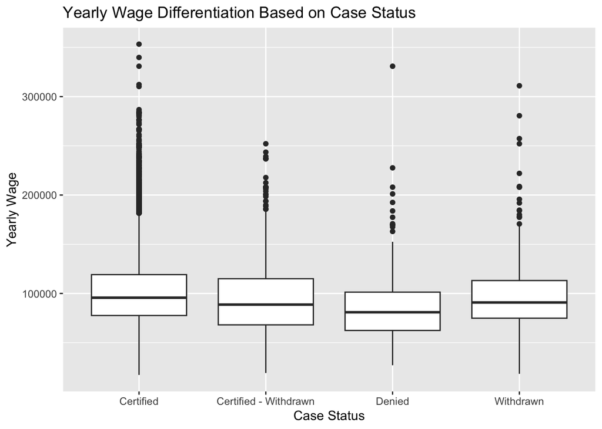

Yearly Wage distriution for the different case statuses

```r
visas %>%
  ggplot(aes(x = CASE_STATUS, y = Yearly_wage)) +
  geom_boxplot() +
  scale_y_continuous(labels = function(x) format (x, scientific = FALSE)) +
  labs(x = "Case Status", y = "Yearly Wage", title = "Yearly Wage Differentiation Based on Case Status")
```

Certified-withdrawn applications average $88,712 yearly, slightly lower than fully withdrawn applications at $93,558. This suggests applicants with higher-wage positions might strategically withdraw before potential denial to maintain cleaner records for reapplication, while certified-withdrawn cases represent routine administrative corrections.

### Average Wage for the 10 Industries with the Highest Number of Certified Cases

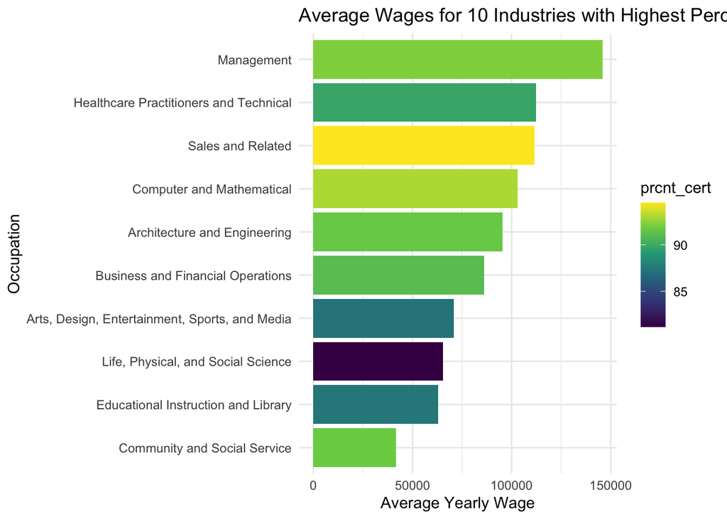

```r
TOP_10 <- visas %>%
  group_by(SOC_TITLE) %>%
  summarise(total_apps = n(),
    certified_count = sum(CASE_STATUS == "Certified", na.rm = TRUE),
    prcnt_cert = 100 * mean(CASE_STATUS == "Certified", na.rm = TRUE),
    avg_wage = mean(Yearly_wage, na.rm = TRUE)) %>%
  arrange(desc(certified_count)) %>%
  slice(1:10) %>%
  ungroup()

ggplot(TOP_10, aes(x = avg_wage, y = reorder(SOC_TITLE, avg_wage), fill=prcnt_cert)) +
  geom_col() +
  labs(title = "Average Wages for 10 Industries with Highest Percentage of Cetified Cases",
    x = "Average Yearly Wage",
    y = "Occupation") +
  scale_fill_viridis_c() +
  theme_minimal()
```

These findings suggest wage level alone doesn’t determine approval likelihood. The lack of a clear wage-certification pattern across industries, combined with geographical wage disparities, indicates that meeting prevailing wage requirements for specific positions and locations matters more than absolute wage amounts. Combined with earlier findings, occupation type emerges as the most influential factor, with wage playing a supporting role.

## Conclusion

- Key takeaways: Tech industry reliance on H-1B visas creates concentrated application volumes in Silicon Valley and major tech hubs. While seasonal filing patterns exist, timing doesn’t affect approval likelihood. Wage levels matter only insofar as they meet prevailing wage requirements for specific positions.
- Limitations: With more time, we would analyze employer-specific patterns, examine cap-subject versus cap-exempt petitions, and investigate denial reasons more deeply to provide applicants with more actionable insights for improving certification chances. Access to applicant demographic data, such as birthplace, age, education, would also allow for a richer study of disparities in certification outcomes.

## References

Bian, Z. (2023). *H1B LCA Disclosure Data (2020-2024)* [Data set]. Kaggle. https://www.kaggle.com/datasets/zongaobian/h1b-lca-disclosure-data-2020-2024

U.S. Department of Labor, Employment and Training Administration. (n.d.). *Foreign Labor Certification Performance Data*. https://www.dol.gov/agencies/eta/foreign-labor/performance